Lima, Peru

# Lucho *Escobedo*

I build organizations that turn data into decisions, value, and durable advantage.

Get in touch [LinkedIn](https://www.linkedin.com/in/luchoescobedo/)

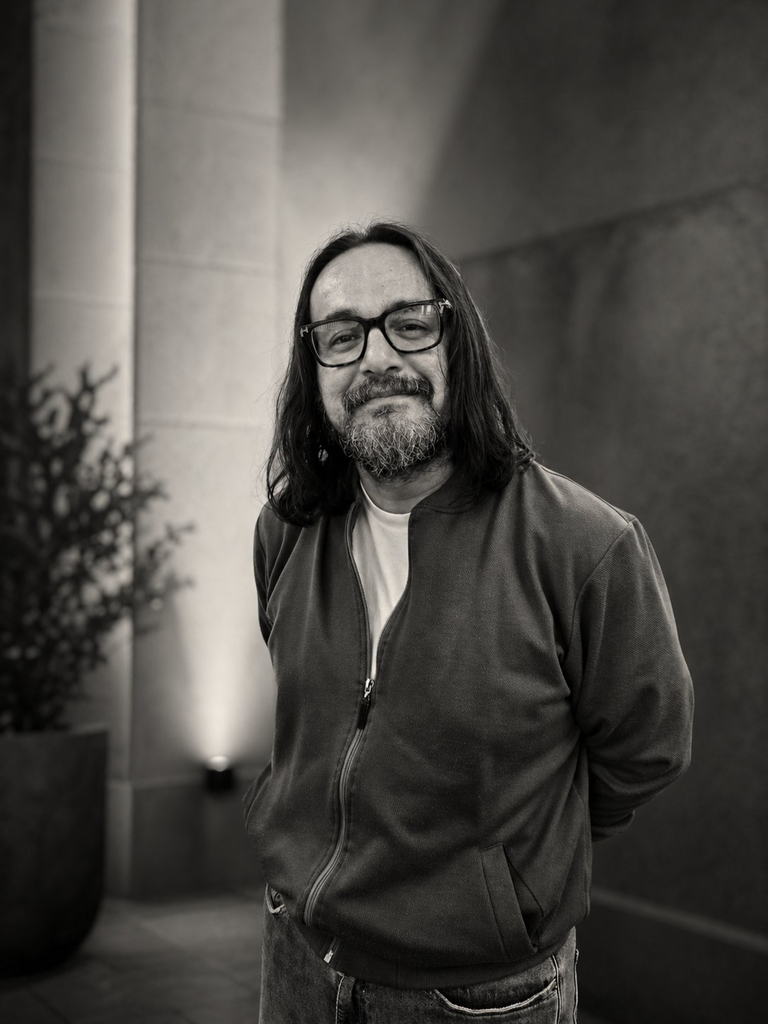

- PhD, Geospatial Economics · University of Illinois
- Fulbright Scholar · Tinker Fellow · CLACSO Fellow
- Spanish · English · Portuguese
- Lima, Peru

Track record

$*1B*+Cumulative business impact

*4*Industries: banking, technology, consulting, consumer goods

*3*Continents: Americas, Europe, Middle East

*20*yrBuilding systems that compound

Capabilities

## What I bring to any *room*

01

### Enterprise Data & AI Platforms

Build and consolidate unified data platforms and AI-oriented architectures to enable scalable, governed operations.

02

### Decision Systems Design

Integrate data, models, and business rules to drive real-time decisions and automate critical processes.

03

### Operating Model Design

Structure and scale data organizations to align engineering, governance, and operations for effective execution.

04

### AI Enablement & Adoption

Translate AI capabilities into business applications through structured development and disciplined deployment.

05

### Governance & Trust Systems

Establish ownership standards and control frameworks to ensure reliable, traceable, and auditable use of data and AI.

06

### Product & Value Strategy

Define value frameworks and strategic roadmaps to align data and AI initiatives with measurable business outcomes.

Ventures

## Building for the *long game*

Advisory · Strategy · 2025

### Kipu

We help organizations make data, technology, and AI meaningful, anchoring capability to how they actually operate, decide, and grow.

Data StrategyAI StrategyAdvisory

[Visit Kipu](https://kipuai.com)

Investment · Acquisition · 2024

### Green Street Holdings

We invest in small businesses to strengthen their foundations, modernize with purpose, and build long-term resilience.

AcquisitionsPartnershipsInvestment

[Visit Green Street](https://greenstreet-holding.com)

Community · Directory · 2025

### BJJ Cerca de Mí

A platform helping BJJ practitioners find verified academies near them. Now live across five Peruvian cities.

BJJLatin AmericaCommunity

[Visit BJJCercaDeMí](https://bjjcercademi.org)

Operations · Fulfillment · Textiles

### Prime Deals

End-to-end design, production, and delivery of high-performance gear and merch for combat sports academies.

OperationsTextilesCombat Sports

[Visit Prime Deals](https://primedeals.global)

Career

## Twenty years of *compounding experience*

Apr 2026 – Present  
Lima, PE

Corporate Director of Data

Yanbal / FERBEL

Leading the corporatization of data, establishing enterprise architecture, governance, and AI-ready foundations across a multinational beauty company.

Aug 2025 – Apr 2026  
Lima, PE

Head of Data & Advanced Analytics

Banco de Credito del Peru (BCP)

Led credit risk analytics spanning strategy, governance, and regulatory alignment across Retail, SME, and Payments at Peru's largest bank.

Jun 2023 – Jul 2025  
Miami, US

Head of Data & Analytics Engineering, HRO

ADP

Unified Analytics Engineering, Data Operations, and Governance into a single operating model. Led a 25-person organization.

May 2020 – Jun 2023  
Miami, US

Director to VP, Data Science & Analytics

REEF Technology

Built the data science function from the ground up. Advanced to VP through three promotions.

Aug 2017 – Aug 2019  
São Paulo, BR

Senior Data Scientist

McKinsey & Company

Led technical delivery and strategic advisory across the Americas at McKinsey's AI arm. Applied solutions across banking, CPG, logistics, and healthcare.

Aug 2013 – Jul 2017  
Champaign, US

Analytics Consultant

CITL, University of Illinois

Advised faculty and researchers on study design, methods, and analysis to support evidence-based academic work.

Jun 2006 – Jun 2010  
Lima, PE

Researcher

GRADE, Group for the Analysis of Development

Produced applied research informing economic and education policy in Peru and across Latin America.

Want the full picture? Request my CV

Writing

## Writing

Institutional Intelligence → The Wolf's Den →

Contact

## Let's create *together*

If you are looking for a strategic partner for your data or technology journey, exploring investment or acquisition opportunities, or think our paths align, reach out.

contact@luchoescobedo.com Send a message

LinkedIn[linkedin.com/in/luchoescobedo](https://www.linkedin.com/in/luchoescobedo/)

Kipukipuai.com

Green Streetgreenstreet-holding.com

BJJ Cerca de Míbjjcercademi.org

Currently open for

Strategic Advisory

Data strategy, AI adoption, organizational transformation. Particularly interested in organizations at an inflection point.

Investment & Acquisition

Small business acquisitions, partnerships, and capital investments through Green Street Holdings.

Speaking & Collaboration

Data leadership, AI strategy, entrepreneurship, and the intersection of physical culture and professional performance.